# Simulation 9: IPW with near positivity violation

Brian Richardson

12/10/2024

```r
rm(list = ls())
library(dplyr)
library(tidyverse)
library(ggplot2)
library(ggh4x)
library(kableExtra)
library(MASS)
```

```r
# load simulation results from each of 10 clusters
setwd(dirname(getwd()))
sim.out.list <- lapply(
  X = 0:9,
  FUN = function(clust) {
    cbind(clust,
          read.csv(paste0("sim_data/sim9_ipw_positivity/sd",
                          clust, ".csv")))
  })


# combine simulation results into 1 data frame
sim.out <- bind_rows(sim.out.list)

# true MSM parameters
g <- c(0, 1, 1)

# number of sims per setting
n.rep <- nrow(sim.out) / n_distinct(dplyr::select(sim.out, n, B, vare))

# make long data frame
sim.out.long <- sim.out %>%
  pivot_longer(cols = starts_with("ghat") |
                 starts_with("stde") |
                 starts_with("bste"),
               names_to = "method.param",
               values_to = "val") %>%
    mutate(method = factor(substr(method.param, 6, 7),
                           levels = c("OI", "NI", "CI"),
                           labels = c("Oracle IPW",
                                      "Naive IPW",
                                      "CS IPW")),
           param = factor(substr(method.param, 9, 9)),
           name = factor(substr(method.param, 1, 4)),
           g.true = g[param]) %>%
  dplyr::select(-method.param) %>%
  group_by(clust, n, B, vare, method, param, name) %>%
  mutate(id = row_number()) %>%
  pivot_wider(names_from = name,
              values_from = val,
              id_cols = c(clust, n, B, vare, method,
                          param, g.true, id)) %>%
  mutate(ci.lower = ghat - qnorm(0.975) * stde,
         ci.upper = ghat + qnorm(0.975) * stde,
         ci.cov = g.true >= ci.lower & g.true <= ci.upper,
         bcci.lower = ghat - qnorm(0.975) * bste,
         bcci.upper = ghat + qnorm(0.975) * bste,
         bcci.cov = g.true >= bcci.lower & g.true <= bcci.upper)
```

The goal of this program is to evaluate the Monte Carlo corrected score inverse probability weighting (MCCS IPW) estimator in the presence of confounding and measurement error, and in a scenario where there is a near positivity violation.

## Setup

Consider the following setup:

- continuous confounder $L \sim N(0, 0.13)$,
- bivariate continuous exposure $\pmb{A} = (A_1, A_2)^T$ with $\pmb{A}|L$ having multivariate normal distribution $N_2\left(\begin{bmatrix} 4L \\ -4L \end{bmatrix}, \begin{bmatrix} 1 & 0 \\ 0 & 1 \end{bmatrix}\right)$.
- mismeasured exposure $\pmb{A}^* = (A^*_1, A^*_2)^T = \pmb{A} + \pmb{\epsilon}$, where $\pmb{\epsilon} = (\epsilon_1, \epsilon_2)^T \sim N(\pmb{0}, \pmb{\Sigma}_e)$, $\pmb{\Sigma}_e = \begin{bmatrix} 0.2 & 0 \\ 0 & 0.2 \end{bmatrix}$.
- normal outcome $Y$ with $\textrm{E}(Y|\pmb{A},L) = \widetilde\gamma_0 + \widetilde\gamma_1 A_1 + \widetilde\gamma_2 A_2 + \widetilde\gamma_3 L$, where $\widetilde{\pmb{\gamma}} = (\widetilde\gamma_0, \widetilde\gamma_1, \widetilde\gamma_2, \widetilde\gamma_3)^T = (0, 1, 1, 1)^T$.

This data generating process leads to the marginal structural model $\textrm{E}\{Y(\pmb{a})\} = \gamma_0 + \gamma_1 a_1 + \gamma_2 a_2$, where $\pmb{\gamma} = (\gamma_0, \gamma_1, \gamma_2)^T = (0, 1, 1)^T$.

The estimand of interest in these simulations is the parameter $\pmb{\gamma}$ in the marginal structural model.

## Methods

In these simulations, we compare three methods:

1. Oracle IPW
2. Naive IPW
3. Corrected IPW

## Results

We first check for simulations with errors.

```r
# summarize proportion of missing data by setting
sim.out.long %>%
  filter(param == 1) %>%
  group_by(method, n, vare, B) %>%
  summarise(prop.error = mean(is.na(ghat))) %>%
  filter(prop.error > 0) %>%
  ungroup()
```

```
## # A tibble: 0 × 5
## # ℹ 5 variables: method <fct>, n <int>, vare <dbl>, B <int>, prop.error <dbl>
```

### Plot of simulation setup

Below is a plot of one simulated data set of size $n=8000$ under the main text setting and under the near positivity violation setting.

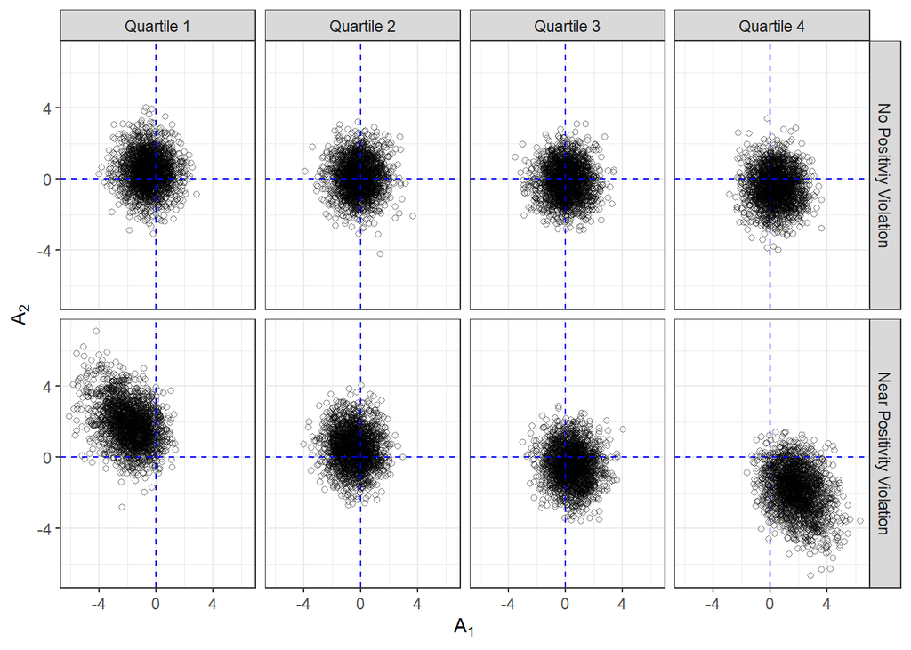

```r
set.seed(1)
nn <- 8000

# no violation parameters
coef.a.l <- matrix(
  data = c(0, 0,
           1, -1,
           0, 0),
  nrow = 3, byrow = T)

# violation parameters
coef.a.l.v <- 4 * coef.a.l

# variance of A|L
var.a.l <- c(1, 1)

# generate data
L <- rnorm(nn, 0, 0.36)                        # confounder
L.grp <- ntile(L, 4)                           # L quartiles
A <- mvrnorm(n = nn,                           # true exposure (no violation)
             mu = c(0, 0),
             Sigma = diag(var.a.l)) +
  cbind(1, L, L^2) %*% coef.a.l
Av <- mvrnorm(n = nn,                          # true exposure (no violation)
             mu = c(0, 0),
             Sigma = diag(var.a.l)) +
  cbind(1, L, L^2) %*% coef.a.l.v
dat <- data.frame(rbind(cbind(0, L.grp, A),
                        cbind(1, L.grp, Av)))
colnames(dat) <- c("pv", "L", "A1", "A2")

pv.labs <- c("No Positiviy Violation",
             "Near Positivity Violation")
names(pv.labs) <- c(0, 1)
L.labs <- paste0("Quartile ", 1:4)
names(L.labs) <- 1:4

# create plot
dat %>%
  ggplot(aes(x = A1,
             y = A2)) +
  geom_point(shape = 1,
             alpha = 0.5) +
  facet_grid(pv ~ L,
             labeller = labeller(pv = pv.labs,
                                 L = L.labs)) +
  geom_vline(xintercept = 0,
             color = "blue",
             linetype = "dashed") +
  geom_hline(yintercept = 0,
             color = "blue",
             linetype = "dashed") +
  labs(x = expression(A[1]),
       y = expression(A[2])) +
  theme_bw()
```

```r
# save plot
setwd(dirname(getwd()))
ggsave("sim_figures/sim9_ipw_positivity.png",
       width = 7,
       height = 4,
       dpi = 300)
```

### Plots of simulation results

Below are boxplots of the empirical distributions of estimators for $\pmb{\gamma}$.

```r
# extract simulation parameters
n <- unique(sim.out$n)
B <- unique(sim.out$B)
vare <- unique(sim.out$vare)

# make labels for plots
n.labs <- paste0("n = ", n)
names(n.labs) <- n

B.labs <- paste0("B = ", B)
names(B.labs) <- B

vare.labs <- paste0("var(e) = ", vare)
names(vare.labs) <- vare

n.labs <- paste0("n = ", n)
names(n.labs) <- n

param.labs <- paste0("\u03b3", c("0", "1", "2", "3"))
names(param.labs) <- 1:4

# colorblind friendly pallette
pal_light <- c('#EE6677', '#228833', '#4477AA', '#CCBB44', '#66CCEE', '#AA3377', '#BBBBBB')
pal_dark <- c('#991122', '#114419', '#223b55', '#6b611d', '#117799', '#55193b', '#5d5d5d')
```

```r
# create plots
make.plot <- function(title = T, y.lim = Inf, vare. = vare) {

  plot <- sim.out.long %>%
    filter(abs(ghat - g.true) < y.lim,
           vare %in% vare.) %>%
    ggplot(
    aes(x = method,
        y = ghat,
        fill = method,
        color = method)) +
    geom_boxplot() +
    stat_summary(fun = mean,
                 geom = "point",
                 shape = 8,
                 size = 2,
                 orientation = "x",
                 show.legend = F) +
    geom_hline(aes(yintercept = g.true),
               linetype = "dashed",
               color = "orange") +
    facet_wrap(n ~ param,
               scales = "free",
               labeller = labeller(n = n.labs,
                                   param = param.labs)) +
    labs(y = "Parameter Estimate",
         fill = "Method",
         color = "Method") +
    theme_bw() +
    theme(axis.title.x = element_blank(),
          axis.ticks.x = element_blank(),
          axis.text.x = element_blank(),
          legend.position = "bottom") +
    scale_fill_manual(values = pal_light) +
    scale_color_manual(values = pal_dark)

  if (title) {
    plot <- plot +
      ggtitle(paste0("Empirical Distribution of Parameter Estimates"),
            subtitle = paste0(n.rep, " simulations per setting"))
  }
  return(plot)
}
```

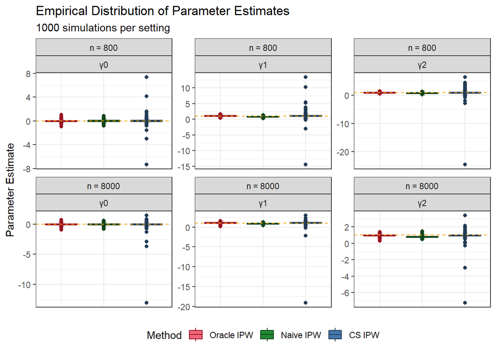

```r
make.plot()
```

### Table of Simulation Results

Below is a table of the empirical bias, empirical standard error, mean estimated standard error, and empirical coverage probability of the 95% CIs corresponding to $\widehat{\pmb{\gamma}}$, for naive and corrected methods, and for $n \in \{800, 8000\}$.

```r
tbl <- sim.out.long %>%
  filter(n %in% c(800, 8000)) %>%
  mutate(Param = paste0("$\\gamma_", as.numeric(param) - 1, "$")) %>%
  group_by(n, method, Param) %>%
  summarise(bias = 100 * mean(ghat - g.true),
            emp.se = 100 * sd(ghat),
            est.se = 100 * mean(stde),
            ci.cov = 100 * mean(ci.cov),
            bcest.se = 100 * mean(bste),
            bcci.cov = 100 * mean(bcci.cov))
kbl <- tbl %>%
  kable(format = "latex",
        digits = c(0, 0, 0,
                   1, 1,
                   1, 1,
                   1, 1),
        align = c(rep("c", 3 + 2),
                  rep("r", 4)),
        booktabs = TRUE,
        linesep = c("", "", "\\addlinespace"),
        escape = FALSE,
        col.names = c("n", "Method", "Parameter",
                      "Bias", "ESE",
                      "ASE", "Cov",
                      "ASE", "Cov")) %>%
  add_header_above(c(" " = 5 + 2,
                     "UC" = 2,
                     "BC" = 2)) %>%
  kable_styling("striped") %>%
  row_spec(row = 0, bold = TRUE)

print(kbl)
```

```
## \begin{table}
## \centering
## \begin{tabular}{cccccrrrr}
## \toprule
## \multicolumn{7}{c}{ } & \multicolumn{2}{c}{UC} & \multicolumn{2}{c}{BC} \\
## \cmidrule(l{3pt}r{3pt}){8-9} \cmidrule(l{3pt}r{3pt}){10-11}
## \textbf{n} & \textbf{Method} & \textbf{Parameter} & \textbf{Bias} & \textbf{ESE} & \textbf{ASE} & \textbf{Cov} & \textbf{ASE} & \textbf{Cov}\\
## \midrule
## 800 & Oracle IPW & $\gamma_0$ & 0.2 & 14.6 & 9.1 & 87.8 & 9.4 & 88.7\\
## 800 & Oracle IPW & $\gamma_1$ & 4.7 & 10.6 & 6.6 & 72.6 & 7.5 & 77.2\\
## 800 & Oracle IPW & $\gamma_2$ & -5.4 & 9.9 & 6.6 & 72.1 & 7.4 & 77.0\\
## \addlinespace
## 800 & Naive IPW & $\gamma_0$ & 0.8 & 15.3 & 10.2 & 88.2 & 10.5 & 89.2\\
## 800 & Naive IPW & $\gamma_1$ & -12.6 & 11.0 & 6.8 & 47.6 & 7.8 & 52.3\\
## 800 & Naive IPW & $\gamma_2$ & -21.2 & 9.9 & 6.8 & 20.1 & 7.7 & 23.0\\
## \addlinespace
## 800 & CS IPW & $\gamma_0$ & 1.0 & 41.4 & 44.4 & 87.9 & 56.3 & 89.7\\
## 800 & CS IPW & $\gamma_1$ & 10.0 & 76.1 & 77.5 & 74.8 & 103.7 & 79.2\\
## 800 & CS IPW & $\gamma_2$ & -4.8 & 88.2 & 86.7 & 82.8 & 136.2 & 84.9\\
## \addlinespace
## 8000 & Oracle IPW & $\gamma_0$ & -0.8 & 10.8 & 6.4 & 90.4 & 6.6 & 91.0\\
## 8000 & Oracle IPW & $\gamma_1$ & 4.2 & 8.2 & 4.5 & 65.6 & 5.2 & 69.9\\
## 8000 & Oracle IPW & $\gamma_2$ & -3.6 & 8.2 & 4.7 & 64.3 & 5.4 & 68.7\\
## \addlinespace
## 8000 & Naive IPW & $\gamma_0$ & -0.4 & 10.7 & 6.8 & 89.1 & 7.0 & 89.5\\
## 8000 & Naive IPW & $\gamma_1$ & -13.0 & 7.9 & 4.6 & 17.9 & 5.1 & 21.6\\
## 8000 & Naive IPW & $\gamma_2$ & -19.9 & 8.0 & 4.6 & 10.2 & 5.1 & 12.2\\
## \addlinespace
## 8000 & CS IPW & $\gamma_0$ & -2.3 & 46.0 & 44.9 & 89.9 & 74.3 & 90.1\\
## 8000 & CS IPW & $\gamma_1$ & 4.4 & 66.4 & 61.9 & 68.0 & 106.0 & 71.5\\
## 8000 & CS IPW & $\gamma_2$ & -4.3 & 33.0 & 31.0 & 76.6 & 49.8 & 78.8\\
## \bottomrule
## \end{tabular}
## \end{table}
```